# Economic Impacts Assessment

Scott Coffin

12/23/2020

# Base Weights

The first basic step to make reliable extrapolations to the population is to generate base weights. Note that this is one of three weight adjustments that will be applied,including non-response and calibration adjustments to weights. The first step in weighing is taking into account the different probabilities of being sampled that respondents may have simply based on proportions in the population. This is also known as generating *base weights*. Note that this survey is a random stratified sampling design without replacement. We will calculate inclusion probabilities for each strata (tags A, B, C, D).

```r
probSumm <- allSmalls %>%
  filter(voluntary != "y") %>% #remove volunteers
  mutate(sample = case_when(requested == "y" ~ 1,requested == "n" ~ 0)) %>% #provide integer tag for sampled
  group_by(tag) %>%
  summarize(N = n(),samples = sum(sample), respondedTotal = sum(response, na.rm = TRUE), prob = samples/N, base.weight = 1/prob,
            sum.base.weight = base.weight * samples, fpc = samples/N) %>%
  drop_na
#join the probability to each sample
allSmalls <- right_join(allSmalls, probSumm, by = "tag")
allSmalls.requested.responded <- right_join(allSmalls.requested.responded, probSumm, by = "tag")
#print
probSumm
```

```
## # A tibble: 4 x 8
##   tag       N samples respondedTotal  prob base.weight sum.base.weight   fpc
##   <fct> <int>   <dbl>          <dbl> <dbl>       <dbl>           <dbl> <dbl>
## 1 Bin A  1914     228            154 0.119        8.39           1914. 0.119
## 2 Bin B   257     133             97 0.518        1.93            257. 0.518
## 3 Bin C   107      84             69 0.785        1.27            107. 0.785
## 4 Bin D    72      65             51 0.903        1.11             72  0.903
```

Note in the code above that *finite population correction* (fpc) is defined as the value of the sampling rate, *n/N* - not *1 - n/N* - which is the textbook definition of the *fpc*. This is an idiosyncracy of the *survey* package in R and is consistent with other programming languages such as Stata or SAS.

```r
scaledSumm <- allSmalls.requested.responded %>%
  group_by(tag) %>%
  summarize(n = n(),  scaled.base.weight = base.weight/N*(samples), sum.scaled.base.weight
            = sum(scaled.base.weight))
allSmalls %>%
  mutate(scaled.base.weight = 1)

allSmalls.requested.responded %>%
  mutate(scaled.base.weight = 1)
#print
head(scaledSumm)
```

[output not shown]

Here we can see that the scaled base weights are nominal (i.e. 1), and all add up to the respondent sample size for each bin. Later we will calcualted non-response weights and multiply them by the scaled base weights.

```r
rm(probSumm, scaledSumm)
probabilities <- allSmalls %>%
  group_by(tag) %>%
  summarise(min.probability = min(prob, na.rm = T),
            mean.probability = mean(prob, na.rm = T),
            max.probability = max(prob, na.rm = T)) %>%
  as.vector()
print(probabilities)
```

```
## # A tibble: 4 x 4
##   tag   min.probability mean.probability max.probability
##   <fct>           <dbl>            <dbl>           <dbl>
## 1 Bin A           0.119            0.119           0.119
## 2 Bin B           0.518            0.518           0.518
## 3 Bin C           0.785            0.785           0.785
## 4 Bin D           0.903            0.903           0.903
```

```r
#check to ensure probabiliities are realistic
#if(probabilities$min.probability < 0){stop("Minimum probability of being sampled is smaller than 0. Review sampling probabilities before computing base weights.")}else if(probabilities$max.probability > 1){stop("Maximum probability of being sampled is larger than 1. Review sampling probabilities before computing base weights.")}
rm(probabilities)
```

There may be underlying factors that make some types of water systems more or less likely to be sampled. For instance, let’s look at the mean probabilities by fee code.

```r
allSmalls %>%
  filter(!is.na(prob)) %>%
  group_by(tag, Fee_Code) %>%
  summarise(n = n(),
    mean.prob.percentage = mean(prob, na.rm = T)*100) %>%
      arrange(desc(mean.prob.percentage)) %>%
  head()
```

```
## # A tibble: 6 x 4
## # Groups:   tag [3]
##   tag   Fee_Code     n mean.prob.percentage
##   <fct> <fct>    <int>                <dbl>
## 1 Bin D C1          60                 90.3
## 2 Bin D DAVCL       12                 90.3
## 3 Bin C C1          83                 78.5
## 4 Bin C DAVCL       25                 78.5
## 5 Bin B C1         175                 51.8
## 6 Bin B DAVCL       86                 51.8
```

Since some fee codes roughly fit within sampling bins (strata), it makes sense that we see discrete groupings. Other factors such as demographics may have other probabilities of being sampled. Let’s see what the difference in probabilities are for months before assistance, which has six discrete levels (A-F).

```r
allSmalls %>%
  group_by(months_before_assist, tag) %>%
  filter(!is.na(months_before_assist)) %>%
  summarise(n = n(),mean.prob.percentage = mean(prob, na.rm = T)*100) %>%
      arrange(desc(mean.prob.percentage)) %>%
  head()
```

```
## # A tibble: 6 x 4
## # Groups:   months_before_assist [6]
##   months_before_assist tag       n mean.prob.percentage
##   <fct>                <fct> <int>                <dbl>
## 1 A                    Bin D     1                 90.3
## 2 B                    Bin D     1                 90.3
## 3 C                    Bin D     2                 90.3
## 4 D                    Bin D     2                 90.3
## 5 E                    Bin D    14                 90.3
## 6 F                    Bin D    29                 90.3
```

To correct for these differential probabilities, we must design weights (sometimes called base weights) so that our sample does not over- or under-represent relevant groups. The design weights are equal to the inverse of the probability of inclusion to the sample. Therefore, the design weight (d0) of a respondent (i) will be equal to: d0[i] = 1/pi[i] where pi[1] is the probability of that unit being included in the sampling.

A simple interpretation of design weights is ‘the number of units in our population that each unit in our sample represents’. There is a simple but important test that we should perform after computing design weights. **The sum of all design weights should be equal to the total number of units in our population.**

Now to ensure design weights sum up to the entire population from which each population (bin) was drawn, we repeat the code from above.

```r
allSmalls %>%
  mutate(sample = case_when(requested == "y" ~ 1,requested == "n" ~ 0)) %>% #provide integer tag for sampled
  group_by(tag) %>%
  summarize(n = n(),samples = sum(sample), prob = samples/n, base.weight = 1/prob,
            sum.base.weight = base.weight* samples) %>%
  drop_na
```

```
## # A tibble: 4 x 6
##   tag       n samples  prob base.weight sum.base.weight
##   <fct> <int>   <dbl> <dbl>       <dbl>           <dbl>
## 1 Bin A  1944     228 0.117        8.53           1944.
## 2 Bin B   265     133 0.502        1.99            265
## 3 Bin C   108      84 0.778        1.29            108.
## 4 Bin D    72      65 0.903        1.11             72
```

# Completeness

Since data are missing for some categories within responses, we have three choices: 1) listwise-deletion: remove rows that contain missing data. This will, of course, reduce the strength of the dataset. 2) mean/median substitution: another quick fix that takes the mean/median of the existing data points and substitutes the missing data points. This would obviously bias the analysis since it decreases variance. 3) Multiple imputation: With this approach, rather than replacing missing values with a single value, we use the distribution of the observed data/variables to estimate multiple possible values for the data points. This allows us to account for the uncertainty around the true value, and obtain approximately unbiased estimates (under certain conditions). Moreover, accounting for uncertainty allows us to calculate standard errors around estimations, which in turn leads to a better sense of uncertainty for the analysis.

To decide which option to use, let’s first examine how much data is missing from our survey.

```r
#make subset of data showing complete cases (rows that have full coverage of variables) for the systems that COMPLETED the survey and were asked to participate (i.e. no volunteers).
sub <- allSmalls.requested.responded %>% select(cash_reserve_unrestricted, cash_reserve_restricted, cash_reserve_total, months_before_assist, delinquent_num_acc, delinquent_amount_dollars)
#how many NA's are present total
#sum(is.na(sub))
#how many complete cases total
#sum(complete.cases(sub))
sum(complete.cases(sub)) / nrow(sub)
```

```
## [1] 0.4123989
```

```r
rm(sub) #keep it clean
## view by item for all smalls that responded, separating volunteers
# volunteerMissing <- allSmalls.volunteers %>%
#   select(cash_reserve_unrestricted, cash_reserve_restricted, cash_reserve_total, months_before_assist, delinquent_num_acc, delinquent_amount_dollars) %>%
#    map_df(function(x) sum(is.na(x))) %>%
#     gather(feature, num_nulls) %>%
#     print(n = 100) %>%
#   arrange(desc(num_nulls))
#
# requestedMissing <-  sub %>%
#     map_df(function(x) sum(is.na(x))) %>%
#     gather(feature, num_nulls) %>%
#     print(n = 100) %>%
#   arrange(desc(num_nulls))
# #tabulate
# right_join(volunteerMissing,requestedMissing,by = "feature") %>%  rename("volunteer" = num_nulls.x, "requested" = num_nulls.y)
# #simple, but long table

completenessSummary <- allSmalls %>%
  filter(voluntary == "y" |voluntary == "n") %>%
  select(voluntary, cash_reserve_unrestricted, cash_reserve_restricted, cash_reserve_total, months_before_assist, delinquent_num_acc, delinquent_amount_dollars) %>%
  group_by(voluntary) %>%
   summarise_all((name = ~sum(is.na(.))/length(.)))
#convert to matrix and transpose
transposed <- as.data.frame(t(as.matrix(completenessSummary[2:7])))
#reassign column names
colnames(transposed) <- c("Requested", "Voluntary")
transposed
```

```
##                            Requested  Voluntary
## cash_reserve_unrestricted 0.28032345 0.33333333
## cash_reserve_restricted   0.53099730 0.51282051
## cash_reserve_total        0.14016173 0.12820513
## months_before_assist      0.06738544 0.02564103
## delinquent_num_acc        0.06469003 0.02564103
## delinquent_amount_dollars 0.08625337 0.10256410
```

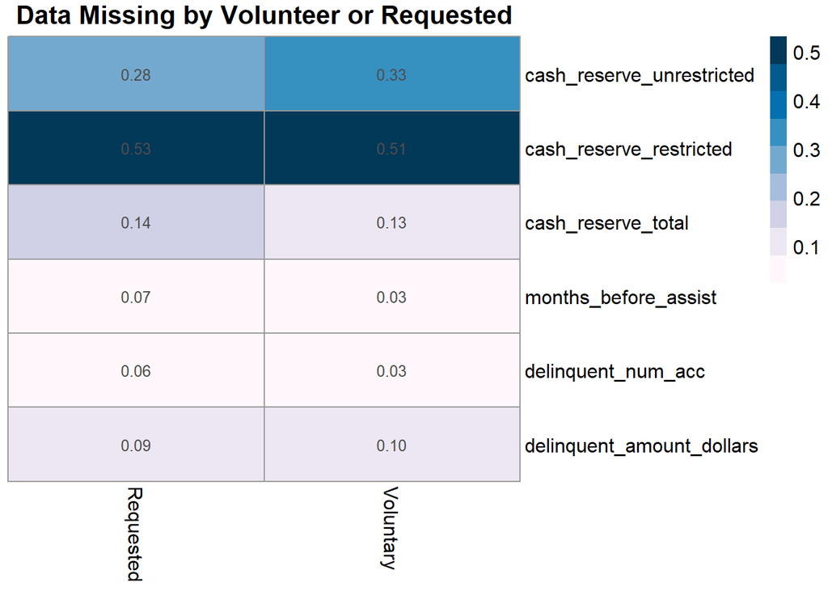

```r
#format as matrix
MissingMatrix <- data.matrix(transposed)
#build heatmap
pheatmap(MissingMatrix,
                           main = "Data Missing by Volunteer or Requested", #title
                           fontsize = 12,
                           cluster_rows = FALSE, cluster_cols = FALSE,#disable dendrograms
                           display_numbers = TRUE,
                           treeheight_row = 0, treeheight_col = 0, #keeps clustering after dropping dendrograms
                           col = brewer.pal(n = 9, name = "PuBu")) #blue color scheme with 9 colors)
```

It’s clear that both the voluntary and requested surveyed water systems provided similiar levels of information in this survey. Let’s see if there were differences in response completeness by sampling bin.

```r
tagCompletenessSummary <- allSmalls %>%
  filter(voluntary == "y" |voluntary == "n") %>%
  select(tag, cash_reserve_unrestricted, cash_reserve_restricted, cash_reserve_total, months_before_assist, delinquent_num_acc, delinquent_amount_dollars) %>%
  group_by(tag) %>%
   summarise_all((name = ~sum(is.na(.))/length(.)))
tagCompletenessSummary
```

```
## # A tibble: 4 x 7
##   tag   cash_reserve_unrestricted cash_reserve_restricted cash_reserve_total
##   <fct>                     <dbl>                   <dbl>              <dbl>
## 1 Bin A                     0.342                   0.630             0.168
## 2 Bin B                     0.248                   0.495             0.0952
## 3 Bin C                     0.257                   0.457             0.143
## 4 Bin D                     0.196                   0.333             0.118
##   months_before_assist delinquent_num_acc delinquent_amount_dollars
##                  <dbl>              <dbl>                     <dbl>
## 1               0.0652             0.0489                    0.0978
## 2               0.0667             0.0952                    0.105
## 3               0.0714             0.0571                    0.0714
## 4               0.0392             0.0392                    0.0392
```

Again, it may be easier to view as a heatmap.

```r
#convert to matrix and transpose
transposedTag <- as.data.frame(t(as.matrix(tagCompletenessSummary[2:7])))
#reassign column names
colnames(transposedTag) <- c("Bin A", "Bin B", "Bin C", "Bin D")
transposedTag
```

```
##                                Bin A      Bin B      Bin C      Bin D
## cash_reserve_unrestricted 0.34239130 0.24761905 0.25714286 0.19607843
## cash_reserve_restricted   0.63043478 0.49523810 0.45714286 0.33333333
## cash_reserve_total        0.16847826 0.09523810 0.14285714 0.11764706
## months_before_assist      0.06521739 0.06666667 0.07142857 0.03921569
## delinquent_num_acc        0.04891304 0.09523810 0.05714286 0.03921569
## delinquent_amount_dollars 0.09782609 0.10476190 0.07142857 0.03921569
```

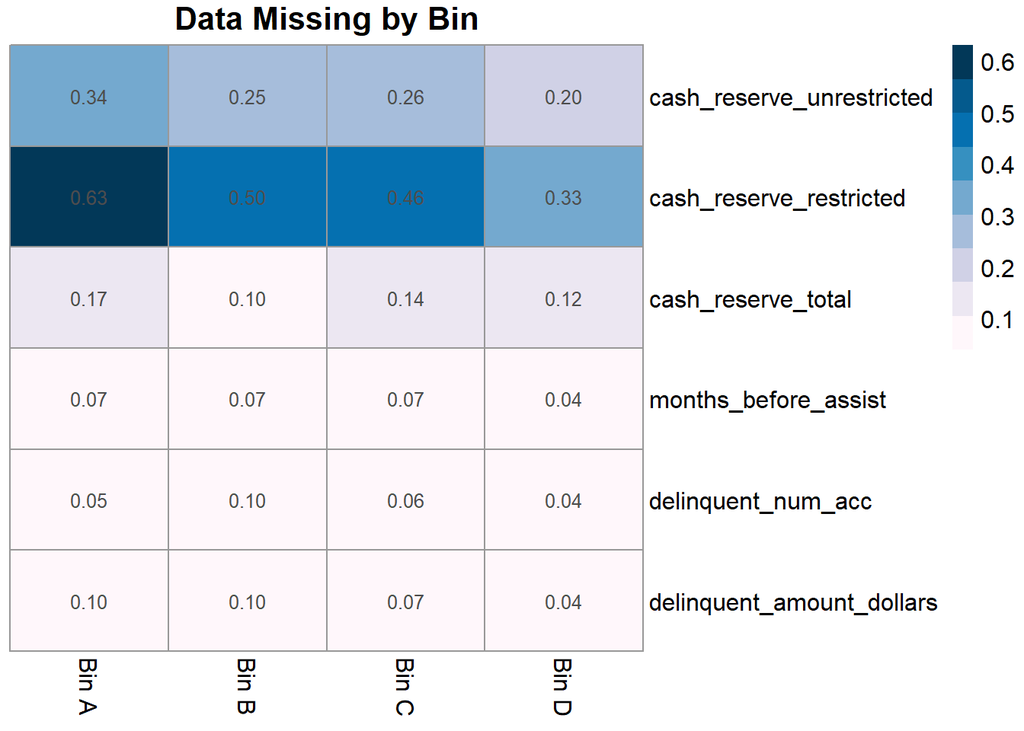

```r
#format as matrix
MissingMatrixTag <- data.matrix(transposedTag)
#build heatmap
pheatmap(MissingMatrixTag,
                           main = "Data Missing by Bin", #title
                           fontsize = 12,
                           cluster_rows = FALSE, cluster_cols = FALSE,#disable dendrograms
                           display_numbers = TRUE,
                           treeheight_row = 0, treeheight_col = 0, #keeps clustering after dropping dendrograms
                           col = brewer.pal(n = 9, name = "PuBu")) #blue color scheme with 9 colors)
```

There seems to be a clear step-wise trend for the willingness to report restricted and unresicted cash reserve by size (Bin A are smallest, Bin D are largest). Luckily, no other trends appear. Let’s see if there’s a relationship between reporting of this value and service connections.

```r
rm(MissingMatrixTag, tagCompletenessSummary, completenessSummary, transposed, transposedTag)
#convert numeric to 1
allSmalls.requested.responded <- allSmalls.requested.responded %>%
  mutate(cash_reserve_restricted_NA = case_when(cash_reserve_restricted >= 0 ~ 1))

#Convert NA to 0
allSmalls.requested.responded$cash_reserve_restricted_NA <- allSmalls.requested.responded$cash_reserve_restricted_NA %>% replace_na(0) %>% as.factor()
#convert to factor
allSmalls.requested.responded <- allSmalls.requested.responded %>%
  mutate(cash_reserve_restricted_NA_yn = case_when(cash_reserve_restricted_NA == "0" ~ "no",
                                                   cash_reserve_restricted_NA == "1" ~ "yes"))
allSmalls.requested.responded$cash_reserve_restricted_NA_yn <- as.factor(allSmalls.requested.responded$cash_reserve_restricted_NA_yn)

#examine relationship of response to restricted reseved cash question with number of  service connections

lgit<- glm(cash_reserve_restricted_NA ~ Service_Connections + Fee_Code,
            data = allSmalls.requested.responded, family = "binomial")
summary(lgit)
```

```
##
## Call:
## glm(formula = cash_reserve_restricted_NA ~ Service_Connections +
##     Fee_Code, family = "binomial", data = allSmalls.requested.responded)
##
## Deviance Residuals:
##     Min       1Q   Median       3Q      Max
## -1.8251  -0.9558  -0.9024   1.1706   1.6287
##
## Coefficients:
##                        Estimate  Std. Error z value Pr(>|z|)
## (Intercept)         -0.89172640  0.31564988  -2.825 0.004727 **
## Service_Connections  0.00018450  0.00005949   3.101 0.001927 **
## Fee_CodeDAVCL        1.23399292  0.34943309   3.531 0.000413 ***
## Fee_CodeDAVCS       -0.19330008  0.65455957  -0.295 0.767755
## Fee_CodeSC           0.30936755  0.35508066   0.871 0.383612
## ---
## Signif. codes:  0 '***' 0.001 '**' 0.01 '*' 0.05 '.' 0.1 ' ' 1
##
## (Dispersion parameter for binomial family taken to be 1)
##
##     Null deviance: 512.89  on 370  degrees of freedom
## Residual deviance: 478.06  on 366  degrees of freedom
## AIC: 488.06
##
## Number of Fisher Scoring iterations: 4
```

Here we can see that a significant relationship exists between number of service connections and the response level for the question regarding restricted cash reserves. There also seems to be a significant relationship between the disadvantaged community larges, which is related to service connections.

This may also be visualized in a conditional density plot.

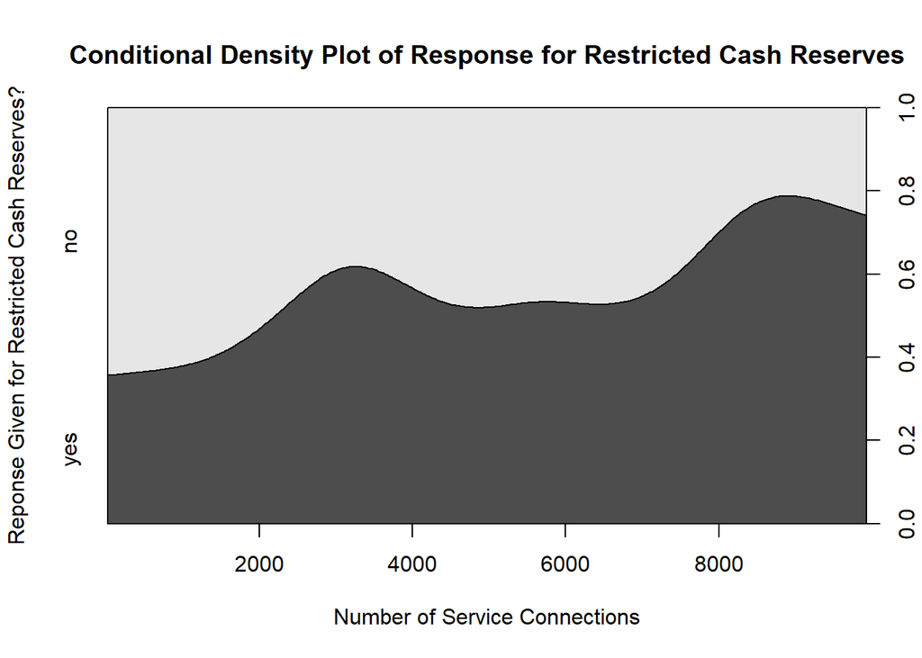

```r
cdplot(cash_reserve_restricted_NA_yn ~ Service_Connections, data = allSmalls.requested.responded,
       main = "Conditional Density Plot of Response for Restricted Cash Reserves", xlab = "Number of Service Connections", ylab = "Reponse Given for Restricted Cash Reserves?")
```

Let’s further test these grouping differences in response with a chi-squared test.

```r
wald.test(b = coef(lgit), #coefficients from logit model
          Sigma = vcov(lgit), #variance covariance matrix of the error terms
          Terms = 3:5) #categorical terms (fee codes)
```

```
## Wald test:
## ----------
##
## Chi-squared test:
## X2 = 13.6, df = 3, P(> X2) = 0.0035
```

The p-value of 0.0035 again suggests that fee code is a significant predictor for willingness to respond to this question. An easier way to conceptualize this may be through odds-ratios.

```r
#exponentiate the coefficients (i.e. create odds-ratios)
round(exp(cbind(OddsRatio = coef(lgit), confint(lgit))),2)
```

```
##                     OddsRatio 2.5 % 97.5 %
## (Intercept)              0.41  0.22   0.75
## Service_Connections      1.00  1.00   1.00
## Fee_CodeDAVCL            3.43  1.76   6.98
## Fee_CodeDAVCS            0.82  0.20   2.81
## Fee_CodeSC               1.36  0.68   2.76
```

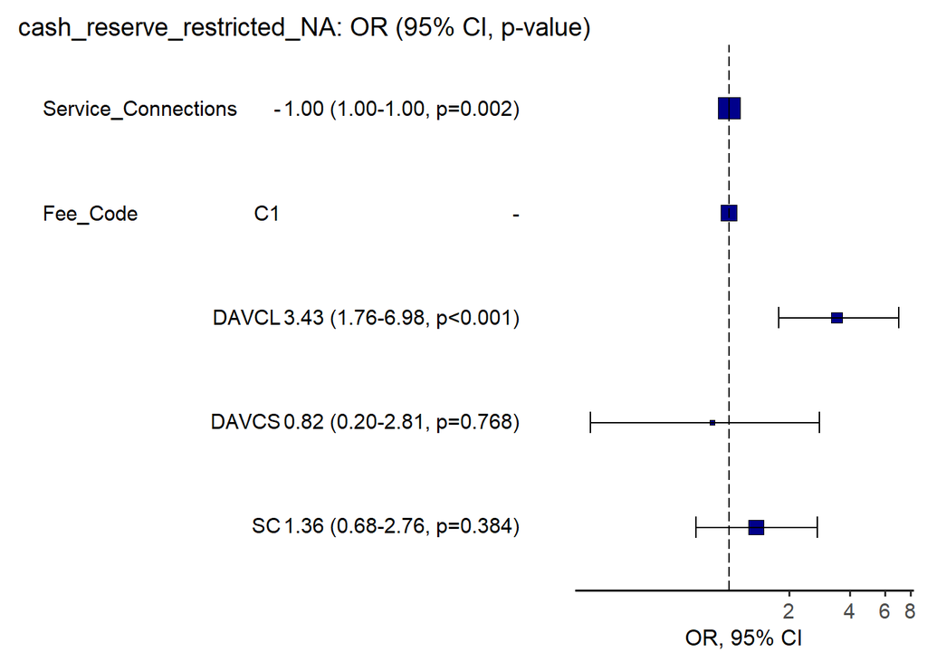

```r
#remove model
rm(lgit)
#define explanatory variables
explanatory = c("Service_Connections", "Fee_Code")
#plot ORs
allSmalls.requested.responded %>%
  or_plot("cash_reserve_restricted_NA",
          explanatory, table_text_size=4, title_text_size=14,
    plot_opts=list(xlab("OR, 95% CI"), theme(axis.title = element_text(size=12))))
```

While data is missing for unrestricted cash reserves, it may be possible to estimate this from other data. This may be easily visualized in a dot plot.

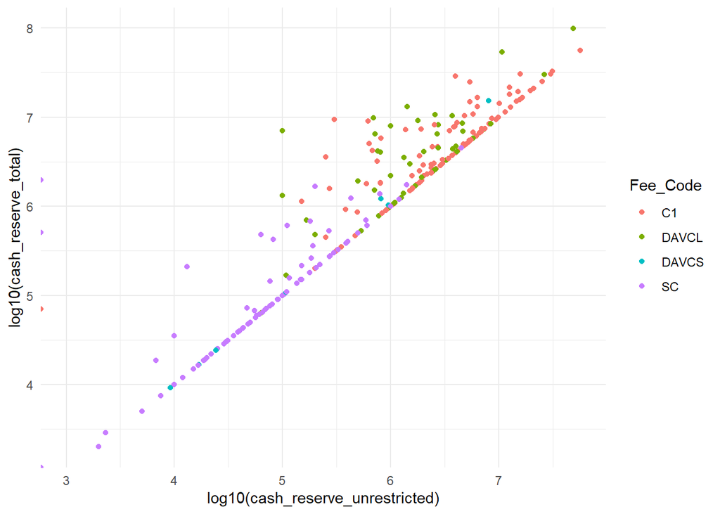

```r
allSmalls.requested.responded %>%
  ggplot(aes(x = log10(cash_reserve_unrestricted), y = log10(cash_reserve_total), color = Fee_Code)) +
  geom_point() +
  theme_minimal()
```

We can see discrete grouping of cash reserve (total and unrestricted) by fee code with community larges (C1) and disadvantaged community larges have higher cash reserves, while small community (SC) and disadvantaged small communities have lower cash reserves. There also seems to be a clear relationship between these variables, with some highly significant outliers. Independent linear regression models may be used to predict missing data, however more sophisticated methods are likely necessary to reliably predict outliers.

Since there are many missing data, we cannot simply rely on single models for each variable. It is therefore necessary to perform multiple imputation to preserve our dataset. I will use the mice (which stands for Multivariate Imputation by Chained Equations) package which is developed by Stef van Buuren. The basic steps of multiple imputation are described by Rubin (1976). *Citation: Rubin, Donald B. 1976. “Inference and missing data.” Biometrika 63, no. 3: 581-592.*

# Multiple Imputation

*The following text is copied, sometimes verbatim, from the [University of Virgina Library] (https://data.library.virginia.edu/getting-started-with-multiple-imputation-in-r/)*

1. impute the missing values by using an appropriate model which incorporates random variation.
2. repeat the first step 3-5 times.
3. perform the desired analysis on each data set by using standard, complete data methods.
4. average the values of the parameter estimates across the missing value samples in order to obtain a single point estimate.
5. calculate the standard errors by averaging the squared standard errors of the missing value estimates. After this, calculate the variance of the missing value parameter across the samples. Finally, combine the two quantities in multiple imputation for missing data to calculate the standard errors.

Put in a simpler way, we a) choose values that keep the relationship in the dataset intact in place of missing values b) create independently drawn imputed (usually 5) datasets c) calculate new standard errors using variation across datasets to take into account the uncertainty created by these imputed datasets (Kropko et al. 2014). *Citation: Kropko, Jonathan, Ben Goodrich, Andrew Gelman, and Jennifer Hill. 2014. “Multiple imputation for continuous and categorical data: Comparing joint multivariate normal and conditional approaches.” Political Analysis 22, no. 4.*

## Missing Data Assumptions

Rubin (1976) classified types of missing data in three categories: MCAR, MAR, MNAR

MCAR: Missing Completely at Random – the reason for the missingness of data points are at random, meaning that the pattern of missing values is uncorrelated with the structure of the data. An example would be a random sample taken from the population: data on some people will be missing, but it will be at random since everyone had the same chance of being included in the sample.

MAR: Missing at Random – the missingness is not completely random, but the propensity of missingness depends on the observed data, not the missing data. An example would be a survey respondent choosing not to answer a question on **income** because they believe the privacy of personal information. As seen in this case, the missing value for income can be predicted by looking at the answers for the personal information question.

MNAR: Missing Not at Random – the missing is not random, it correlates with unobservable characteristics unknown to a researcher. An example would be social desirability bias in survey – where respondents with certain characteristics we can’t observe systematically shy away from answering questions on racial issues.

All multiple imputation techniques start with the MAR assumption. While MCAR is desirable, in general it is unrealistic for the data. Thus, researchers make the assumption that missing values can be replaced by predictions derived by the observable portion of the dataset. This is a fundamental assumption to make, otherwise we wouldn’t be able to predict plausible values of missing data points from the observed data.

There are two approaches to multiple imputation, implemented by different packages in R:

- Joint Multivariate Normal Distribution Multiple Imputation: The main assumption in this technique is that the observed data follows a multivariate normal distribution. Therefore, the algorithm that R packages use to impute the missing values draws values from this assumed distribution. Amelia and norm packages use this technique. The biggest problem with this technique is that the imputed values are incorrect if the data doesn’t follow a multivariate normal distribution.
- Conditional Multiple Imputation: Conditional MI, as indicated in its name, follows an iterative procedure, modeling the conditional distribution of a certain variable given the other variables. This technique allows users to be more flexible as a distribution is assumed for each variable rather than the whole dataset.

If our data appears highly normal, we may use the first option. Let’s examine service connections.

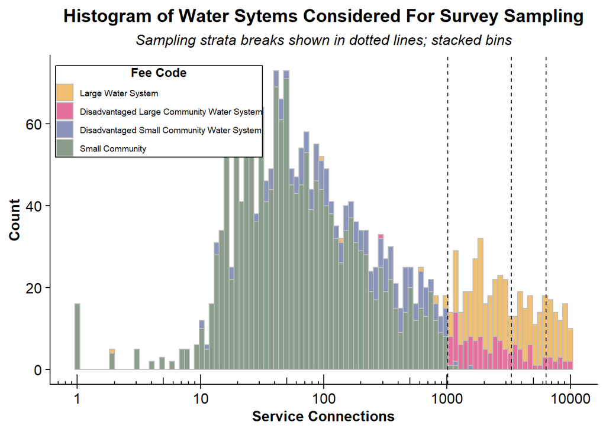

```r
allSmalls %>%
ggplot(aes(x = Service_Connections, fill = Fee_Code)) +
  geom_histogram(position = "stack",alpha=0.6, bins = 100, color = "gray") +
  scale_x_log10() +
  annotation_logticks(base = 10, sides = "b")+ #only bottom
  labs(x='Service Connections',y = "Count",
       title = "Histogram of Water Sytems Considered For Survey Sampling", subtitle = "Sampling strata breaks shown in dotted lines; stacked bins")+
  scale_fill_manual(name = "Fee Code",
                    labels = c("Large Water System", "Disadvantaged Large Community Water System", "Disadvantaged Small Community Water System", "Small Community"),
                    values = cal_palette("superbloom3"))+
  geom_vline(xintercept = c(1009, 3315, 6360), linetype ='dashed') +
    theme_half_open() +
  theme(legend.position = c(0.01, 0.83),
         legend.box.background = element_rect(color = "black"),
         legend.title = element_text(size = 10, face = "bold", hjust = 0.5),
         legend.text = element_text(size = 7),
         plot.title = element_text(size = 15, face = "bold", hjust = 0.5),
         plot.subtitle = element_text(size = 12, hjust = 0.5, face = "italic"),
         axis.title = element_text(size = 12, face = "bold",),
         axis.text = element_text(size = 12))
```

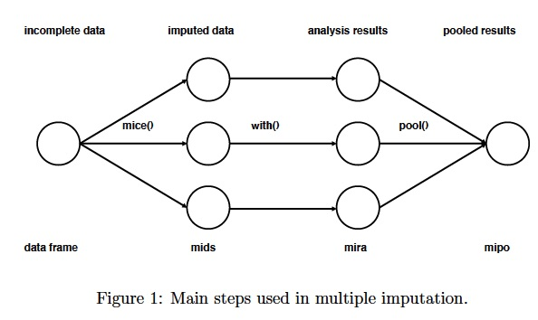

Three main steps to impute data. Source: University of Virgina Library

## Mice Overview

As the first step, the *mice* command creates several complete datasets (in the figure above, n=3). It considers each missing value to follow a specific distribution, and draws from this distribution a plausible value to replace the missing value.

These complete datasets are stored in an object class called *mids*, short for multiply imputed dataset. These datasets are copies of the original dataframe except that missing values are now replaced with values generated by mice. Since these values are generated, they create additional uncertainty about what the real values of these missing data points are. We will need to factor in this uncertainty in the future as we are estimating the regression coefficients from these datasets.

Finally, we pool together the 3 coefficients estimated by the imputed dataset into 1 final regression coefficient, and estimate the variance using the *pool* command. With the assumption that regression coefficients are obtained from a multivariate normal distribution, in order to obtain the final coefficient we just take the mean of 3 values. We calculate the variance of the estimated coefficient by factoring in the within (accounting for differences in predicted values from the dataset regarding each observation) and between (accounting for differences between 3 datasets) imputation variance.

## Mice Implementation

First let’s start my building an Ordinary Least Squares (OLS) linear regression to predict cash in reserve (total) based on relevant predictors for all systems (e.g. service connections, median 12 month household income, delinquent number of accounts, delinquent amout in dollars, CalEnvrioScreen 3 scores). We will ignore the volunteer data for now.

```r
## Estimate an OLS Regression
fitols <- lm(cash_reserve_total ~ Service_Connections + Population + Median_12month_HH_income +
               Median_rent_pct_income + CES_3.0_Score + delinquent_num_acc +
               delinquent_amount_dollars, na.action = na.omit,
             data = allSmalls.requested.responded)
summary(fitols)
```

```
##
## Call:
## lm(formula = cash_reserve_total ~ Service_Connections + Population +
##     Median_12month_HH_income + Median_rent_pct_income + CES_3.0_Score +
##     delinquent_num_acc + delinquent_amount_dollars, data = allSmalls.requested.responded,
##     na.action = na.omit)
##
## Residuals:
##       Min        1Q    Median        3Q       Max
## -16103839  -1900102   -843153    528138  94820450
##
## Coefficients:
##                              Estimate  Std. Error t value Pr(>|t|)
## (Intercept)                970863.053 3833793.073   0.253 0.800265
## Service_Connections          1020.848     454.017   2.248 0.025304 *
## Population                    169.968     110.159   1.543 0.123950
## Median_12month_HH_income       -3.920      19.573  -0.200 0.841385
## Median_rent_pct_income      43364.437   89849.833   0.483 0.629725
## CES_3.0_Score              -64819.856   39300.586  -1.649 0.100173
## delinquent_num_acc          -5896.743    1683.818  -3.502 0.000535 ***
## delinquent_amount_dollars      12.890       4.716   2.733 0.006658 **
## ---
## Signif. codes:  0 '***' 0.001 '**' 0.01 '*' 0.05 '.' 0.1 ' ' 1
##
## Residual standard error: 7879000 on 287 degrees of freedom
##   (76 observations deleted due to missingness)
## Multiple R-squared:  0.2641, Adjusted R-squared:  0.2461
## F-statistic: 14.71 on 7 and 287 DF,  p-value: 0.0000000000000002246
```

As we can see in the table above, a significant number of observations were deleted due to missingness (76 out of 371). Since this is greater than 14% of the whole dataset, our survey would be limited in power.

Time to impute. First we need to prepare the dataset for imputation. It’s best to keep it in it’s rawest form, so any categorical factors should be left as so, instead of using the ordinal transformed variable from above. Further, we want to remove variables that have haver than 25% missing values because they may mess up the imputation. It’s also important to remove variables that are highly correlated with others so as to stop the imputation working otherwise. Additionally, any extreme outliers should be removed, as they may dramatically impact results.

```r
require(reshape2)
```

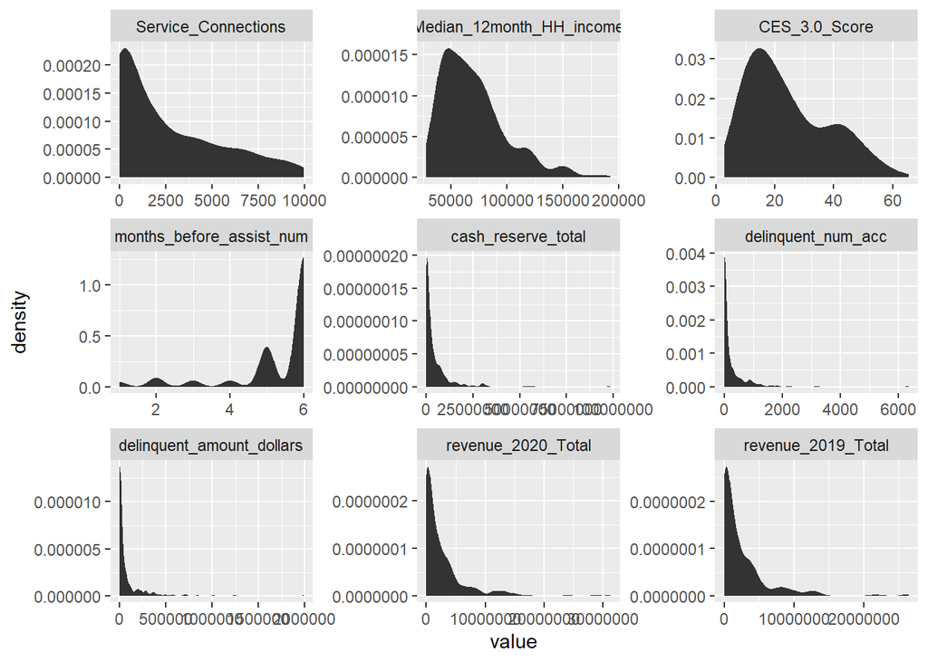

```r
allSmalls.requested.responded %>%
  select(PWSID, Service_Connections,  Median_12month_HH_income, CES_3.0_Score,
         months_before_assist_num, cash_reserve_total, delinquent_num_acc, delinquent_amount_dollars,
         revenue_2020_Total, revenue_2019_Total) %>%
  melt() %>%  #convert wide to long
  ggplot(aes(x = value)) +
  stat_density() +
  facet_wrap(~variable, scales = "free")
```

Everything looks more or less realistic, however would benefit from log10 transformation for visualizing and possibly for statistics.

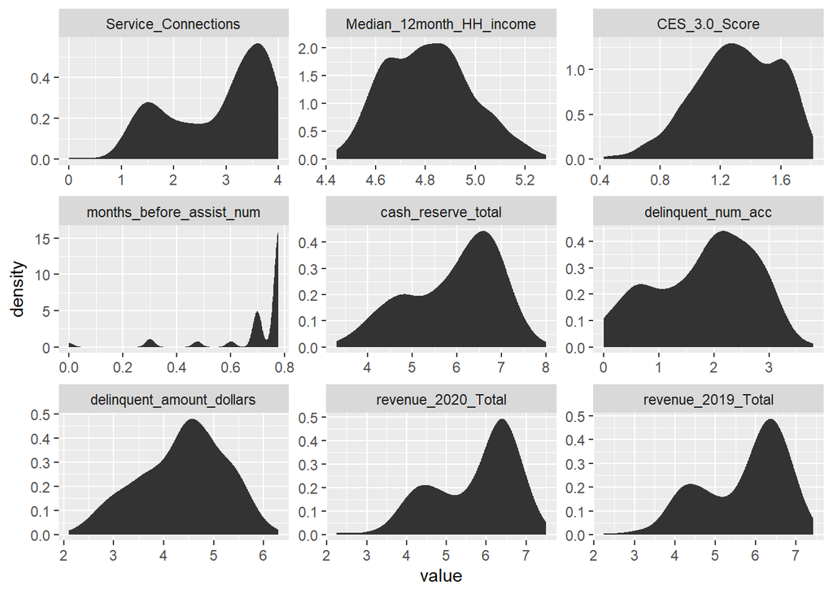

```r
require(reshape2)
allSmalls.requested.responded %>%
  select(PWSID, Service_Connections,  Median_12month_HH_income, CES_3.0_Score,
         months_before_assist_num, cash_reserve_total, delinquent_num_acc, delinquent_amount_dollars,
         revenue_2020_Total, revenue_2019_Total) %>%
  mutate_if(~is.numeric(.) && (.) > 0, log10) %>%
  melt() %>%  #convert wide to long
  ggplot(aes(x = value)) +
  stat_density() +
  facet_wrap(~variable, scales = "free")
```

Now distributions look more or less “normal.”

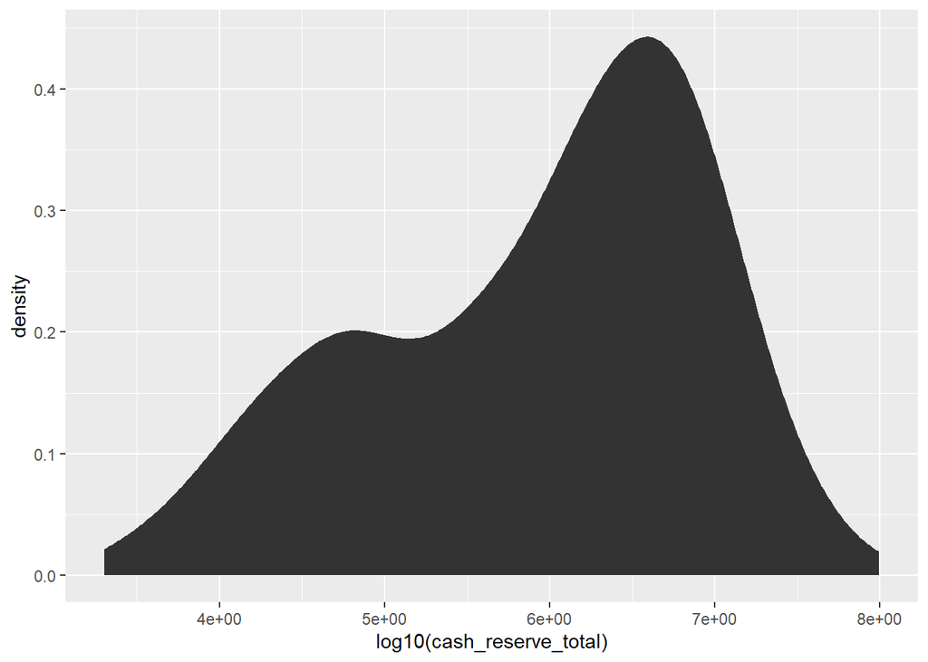

```r
allSmalls.requested.responded %>%
  filter(cash_reserve_total < 1000000000) %>%
  ggplot(aes(x = log10(cash_reserve_total ))) +
  scale_x_continuous(labels = scales::scientific) +
  stat_density()
```

```r
allSmalls.requested.responded %>%
  #filter(cash_reserve_total > 100000) %>%
  select(PWSID, cash_reserve_total, Service_Connections, Population, Fee_Code, Regulating_Agency, Water_System_Name, comments_cash_reserves, comments_exp_rev, months_before_assist, delinquent_num_acc) %>%
  arrange(desc(cash_reserve_total)) %>%
  head()
```

```
##       PWSID cash_reserve_total Service_Connections Population Fee_Code
## 1 CA3310048           98514858                1586       4300    DAVCL
## 2 CA1910204           56365000                7498      31204       C1
## 3 CA2410001           53592144                8419      29479    DAVCL
## 4 CA3710016           32517738                8254      44726       C1
## 5 CA3710023           30700000                6461      24509       C1
## 6 CA5610063           30512751                8751      30000       C1
##             Regulating_Agency               Water_System_Name
## 1     DISTRICT 20 - RIVERSIDE       COACHELLA VWD: I.D. NO. 8
## 2       DISTRICT 16 - CENTRAL LOS ANGELES CWWD 29 & 80-MALIBU
## 3        DISTRICT 11 - MERCED                 CITY OF ATWATER
## 4     DISTRICT 14 - SAN DIEGO            RAINBOW MUNICIPAL WD
## 5     DISTRICT 14 - SAN DIEGO                   SANTA FE I.D.
## 6 DISTRICT 06 - SANTA BARBARA          CAMROSA WATER DISTRICT
##                                                                                                                                                                                    comments_cash_reserves
```

[output cut: 20 more lines]

```r
p_missing <- unlist(lapply(allSmalls.responded, function(x) sum(is.na(x))))/nrow(smalls)
sort(p_missing[p_missing > 0], decreasing = TRUE)
```

[output not shown]

Many of these variables are missing at high rates, such as sub-metered status,and unrestricted cash reserve. I’ll remove those. Also, the monetary values are bins and are not “missing” so much as they are just formatted long-wise binary. We’ll remove those too.

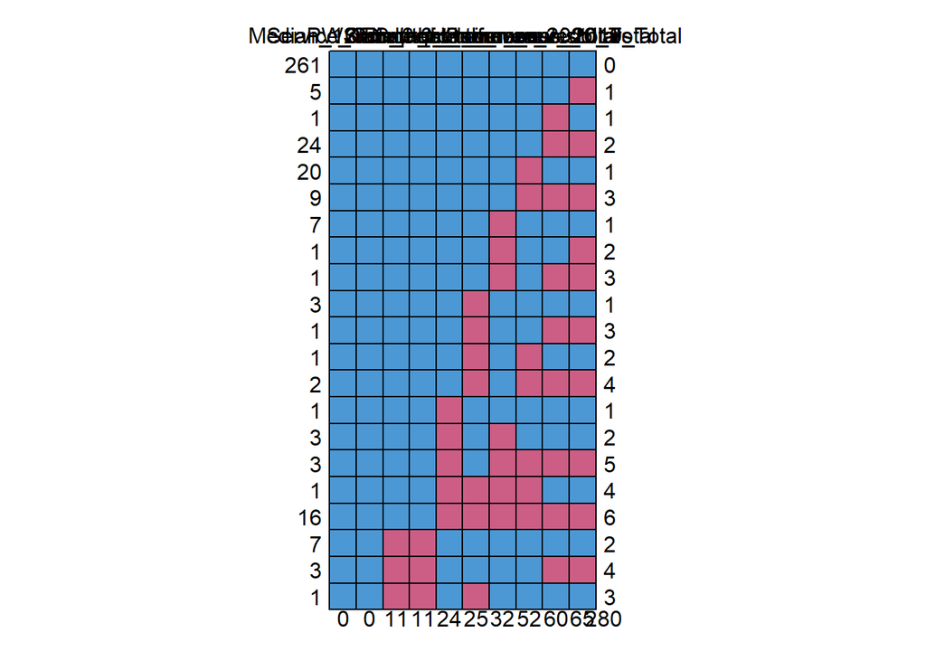

```
##     PWSID Service_Connections Median_12month_HH_income CES_3.0_Score
## 261     1                   1                        1             1
## 5       1                   1                        1             1
## 1       1                   1                        1             1
## 24      1                   1                        1             1
## 20      1                   1                        1             1
## 9       1                   1                        1             1
## 7       1                   1                        1             1
## 1       1                   1                        1             1
## 1       1                   1                        1             1
## 3       1                   1                        1             1
## 1       1                   1                        1             1
## 1       1                   1                        1             1
## 2       1                   1                        1             1
## 1       1                   1                        1             1
```

[output cut: 54 more lines]

```r
#define sub dataset
allSmalls.simple <- allSmalls.requested.responded %>%
  select(PWSID, Service_Connections,  Median_12month_HH_income, CES_3.0_Score, months_before_assist, cash_reserve_total, delinquent_num_acc, delinquent_amount_dollars, revenue_2020_Total, revenue_2019_Total)

#split the other half of the dataset for easy joining
allSmalls.rest <- allSmalls %>%
  filter(requested ==  "y") %>%
  filter(responded == "y") %>%
  select(-Service_Connections, -Median_12month_HH_income, -CES_3.0_Score, -months_before_assist, -cash_reserve_total, -delinquent_num_acc, -delinquent_amount_dollars, -revenue_2020_Total, -revenue_2019_Total)
#see missing values
md.pattern(allSmalls.simple)
```

At this step, we need to specify distributions for our to-be imputed variables and determine which variable we would like to leave out of the imputation prediction process. We will extract information on the predictor matrix and imputation methods to change them.

The *mice* package assumes a distribution for each variable and imputes missing variables according to that distribution. Hence, it is important to correctly specify each of these distributions. *mice* automatically chooses distributions for variables. If we would like to change them, we can do it by changing the methods’ characteristics.

```r
# We run the mice code with 0 iterations
imp <- mice(allSmalls.simple, maxit=0)

# Extract predictorMatrix and methods of imputation
predM <- imp$predictorMatrix
meth <- imp$method

# Setting values of variables I'd like to leave out to 0 in the predictor matrix
predM[, c("PWSID")] <- 0 #name variable need not be considered
# If you like, view the first few rows of the predictor matrix
#head(predM)

# Specify a separate imputation model for variables of interest
# Ordered categorical variables
poly <- c("months_before_assist")

# Dichotomous variable
#log <- c("")

# Unordered categorical variable
#poly2 <- c("voluntary")

# Turn their methods matrix into the specified imputation models
meth[poly] <- "polr"
#meth[log] <- "logreg"
#meth[poly2] <- "polyreg"
meth
```

```
##                     PWSID       Service_Connections  Median_12month_HH_income
##                        ""                        ""                     "pmm"
##             CES_3.0_Score      months_before_assist        cash_reserve_total
##                     "pmm"                    "polr"                     "pmm"
##        delinquent_num_acc delinquent_amount_dollars        revenue_2020_Total
##                     "pmm"                     "pmm"                     "pmm"
##        revenue_2019_Total
##                     "pmm"
```

Our variables of interest are now configured to be imputed with the imputation method we specified. Empty cells in the method matrix means that those variables aren’t going to be imputed.We are now ready for multiple imputation. This step may take a few minutes.

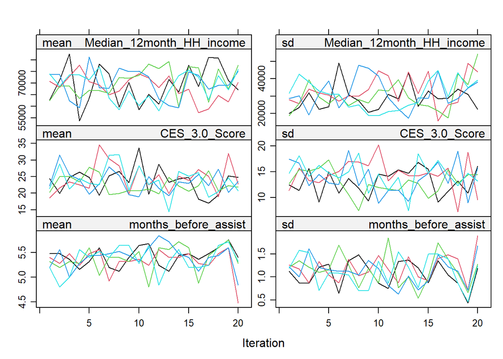

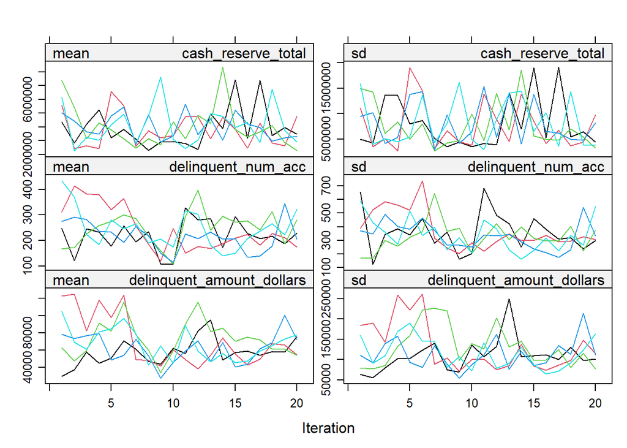

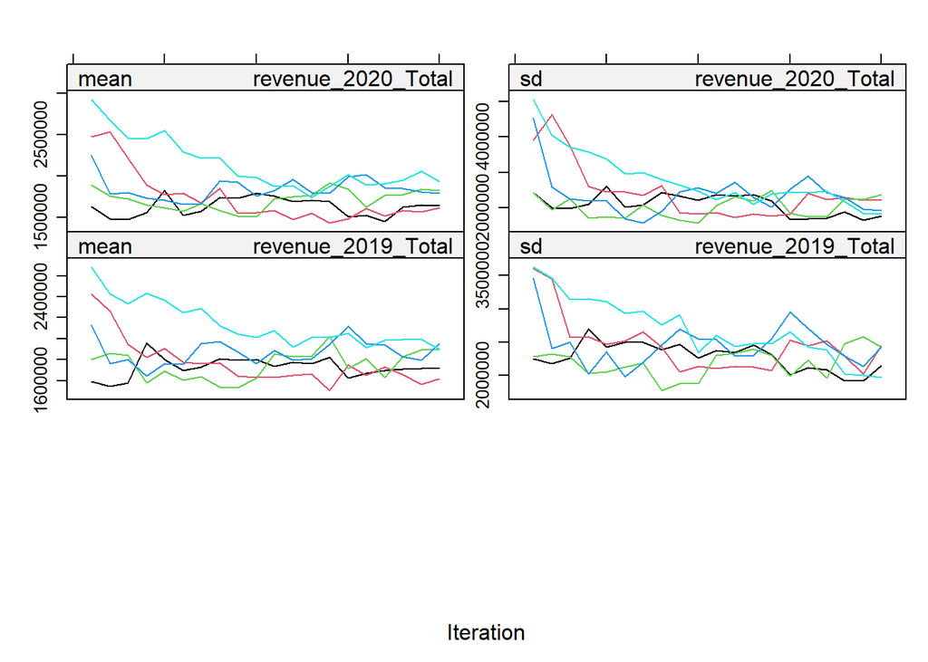

```r
#There is a special function called quickpred() for a quick selection procedure of predictors, which can be handy for datasets containing many variables. selecting predictors according to data relations with a minimum correlation of ρ=.30 can be done by:
ini <- mice(allSmalls.simple, pred=quickpred(allSmalls.simple, mincor=.3), print=F,
            maxit = 20)
plot(ini)
```

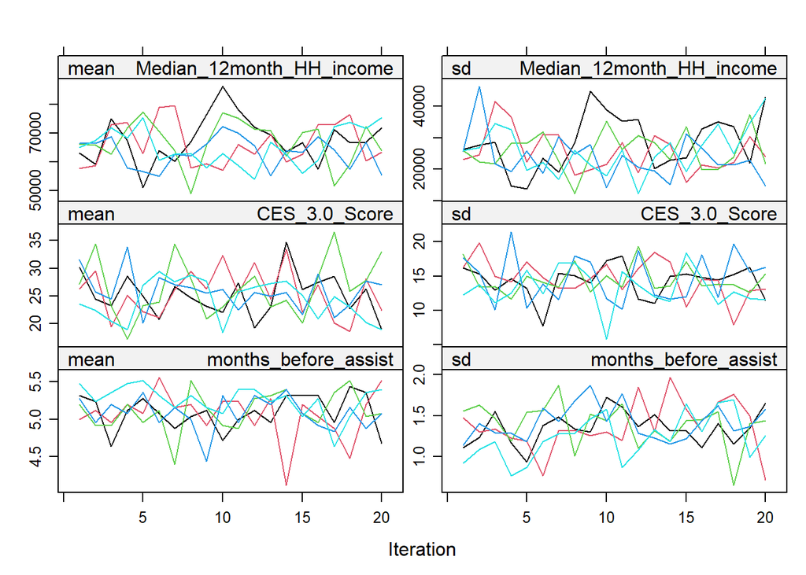

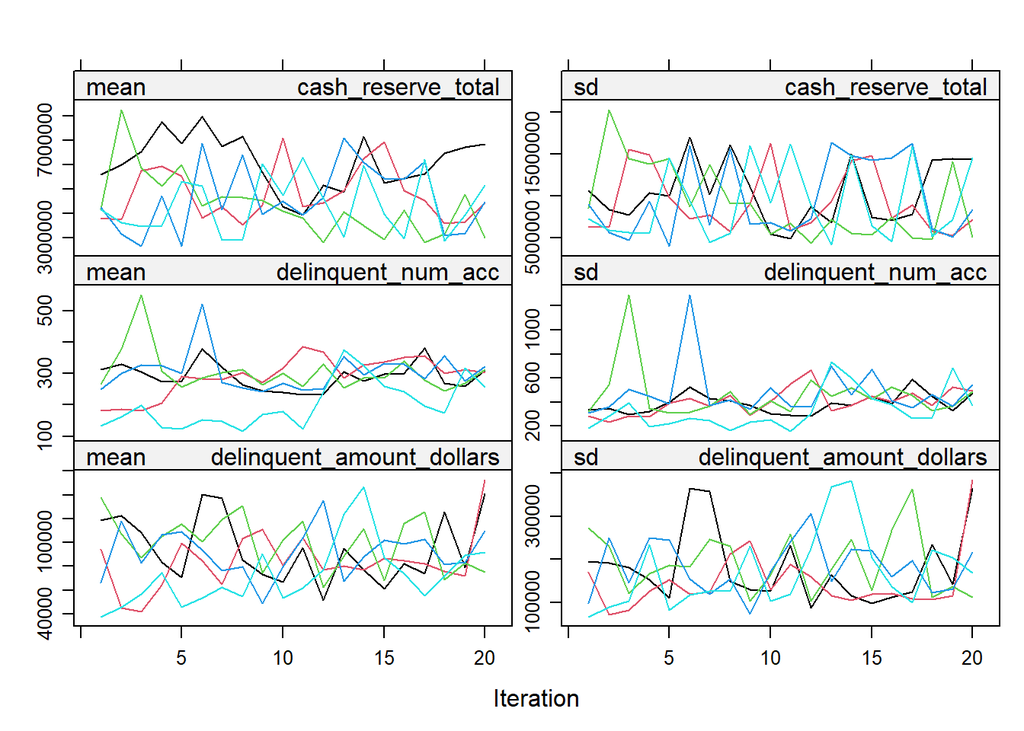

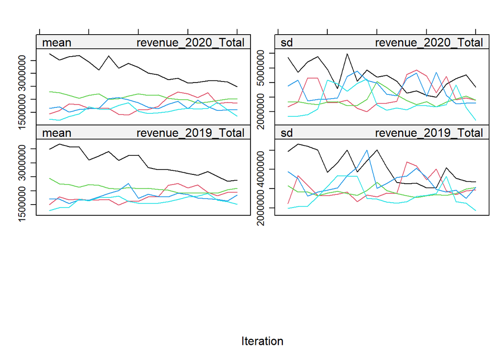

```r
# With this command, we tell mice to impute the subset data, create 5 datasets, use predM as the predictor matrix and don't print the imputation process. If you would like to see the process, set print as TRUE
imp2 <- mice(allSmalls.simple,
             maxit =20, #may want to extend to 40
             predictorMatrix = predM,
             nnet.MaxNWts = 3000, # increase max neural network weights
             method = "cart", #Classification and regression trees method
             print =  FALSE)
plot(imp2)
```

The *mice()* function implements an iterative Markov Chain Monte Carlo type of algorithm. The plots above show the mean(left) and standard deviation(right) of the imputed values. In general, we would like the streams to intermingle and be free of any trends at the later iterations.

Let’s run further diagnostics. Generally, one would prefer for the imputed data to be plausible values, i.e. values that could have been observed if they had not been missing. In order to form an idea about plausibility, one may check the imputations and compare them against the observed values. If we are willing to assume that the data are missing completely at random (MCAR), then the imputations should have the same distribution as the observed data. In general, distributions may be different because the missing data are MAR (or even MNAR). However, very large discrepancies need to be screened. Let us plot the observed and imputed data of total cash reserve.

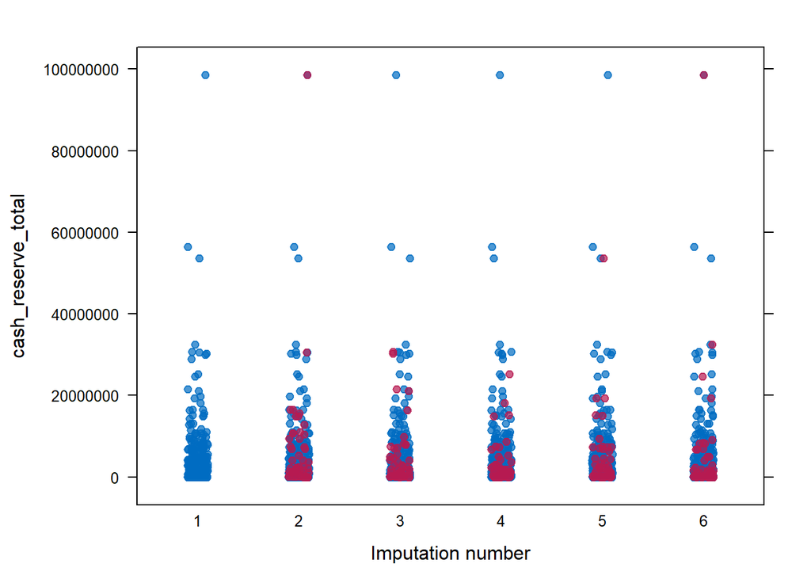

```r
# inspect quality of imputations
stripplot(imp2, cash_reserve_total~.imp, pch = 19, xlab = "Imputation number")
```

We can see above that the imputed values are indeed realistic. Let’s examine the other variables.

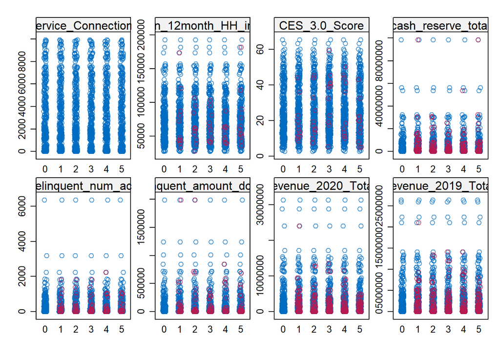

```r
stripplot(imp2)
```

```r
#First, turn the datasets into long format
allSmalls.simple_long <- mice::complete(imp2, action="long", include = TRUE)

# #provide integer tag for voluntary status
# allSmalls.simple_long %<>%
#   mutate(volunteered = case_when(voluntary == "y" ~ 1,voluntary == "n" ~ 0))
#provide integer tag for loan status

# Convert back to mids type - mice can work with this type
allSmalls.simple_long_mids <- as.mids(allSmalls.simple_long)
# Regression

fitimp <- with(allSmalls.simple_long_mids,
  lm(months_before_assist_num ~ Service_Connections + Median_12month_HH_income + Median_rent_pct_income + CES_3.0_Score + delinquent_num_acc + volunteered + delinquent_amount_dollars, na.action = na.omit, data = allSmalls.responded))

summary(pool(fitimp))
```

```
##                        term         estimate       std.error  statistic
## 1               (Intercept)  4.5795100195280 0.5259296202924  8.7074579
## 2       Service_Connections  0.0000252272303 0.0000292580157  0.8622331
## 3  Median_12month_HH_income  0.0000066316540 0.0000028158423  2.3551226
## 4    Median_rent_pct_income  0.0192089051312 0.0122867983298  1.5633776
## 5             CES_3.0_Score -0.0110661839976 0.0052732060727 -2.0985685
## 6        delinquent_num_acc -0.0005409444659 0.0002575333814 -2.1004829
## 7               volunteered -0.4053639147646 0.2362214347617 -1.7160336
## 8 delinquent_amount_dollars -0.0000002359419 0.0000007066833 -0.3338722
##         df    p.value
## 1 341.9828 0.00000000
## 2 341.9828 0.38916345
## 3 341.9828 0.01908102
## 4 341.9828 0.11888867
## 5 341.9828 0.03658799
## 6 341.9828 0.03641824
## 7 341.9828 0.08706152
## 8 341.9828 0.73868064
```

We can compare the pooled coefficients and p-values from the imputed datasets to see if any trends are altered (either become more pronounced or less). They should be similiar to the listwise-deletion technique.

Let’s look at the fmi and lambda. These should be quite low for a good model.

```r
pool(fitimp)
```

```
## Class: mipo    m = 5
##                        term m         estimate                  ubar b
## 1               (Intercept) 5  4.5795100195280 0.2766019655008780109 0
## 2       Service_Connections 5  0.0000252272303 0.0000000008560314812 0
## 3  Median_12month_HH_income 5  0.0000066316540 0.0000000000079289679 0
## 4    Median_rent_pct_income 5  0.0192089051312 0.0001509654131979459 0
## 5             CES_3.0_Score 5 -0.0110661839976 0.0000278067022851698 0
## 6        delinquent_num_acc 5 -0.0005409444659 0.0000000663234425403 0
## 7               volunteered 5 -0.4053639147646 0.0558005662408733727 0
## 8 delinquent_amount_dollars 5 -0.0000002359419 0.0000000000004994012 0
##                       t dfcom       df riv lambda         fmi
## 1 0.2766019655008780109   344 341.9828   0      0 0.005797391
## 2 0.0000000008560314812   344 341.9828   0      0 0.005797391
## 3 0.0000000000079289679   344 341.9828   0      0 0.005797391
## 4 0.0001509654131979459   344 341.9828   0      0 0.005797391
## 5 0.0000278067022851698   344 341.9828   0      0 0.005797391
## 6 0.0000000663234425403   344 341.9828   0      0 0.005797391
## 7 0.0558005662408733727   344 341.9828   0      0 0.005797391
## 8 0.0000000000004994012   344 341.9828   0      0 0.005797391
```

We can see that these values are very low. Let’s compare to the default model.

```r
#First, turn the datasets into long format
allSmalls.simple_long_1 <- mice::complete(imp, action="long", include = TRUE)

# #provide integer tag for voluntary status
# allSmalls.simple_long %<>%
#   mutate(volunteered = case_when(voluntary == "y" ~ 1,voluntary == "n" ~ 0))
#provide integer tag for loan status

# Convert back to mids type - mice can work with this type
allSmalls.simple_long_mids_1 <- as.mids(allSmalls.simple_long_1)
# Regression

fitimp_1 <- with(allSmalls.simple_long_mids_1,
  lm(months_before_assist_num ~ Service_Connections + Median_12month_HH_income + Median_rent_pct_income + CES_3.0_Score + delinquent_num_acc + volunteered + delinquent_amount_dollars, na.action = na.omit, data = allSmalls.responded))

summary(pool(fitimp_1))
```

```
##                        term         estimate       std.error  statistic
## 1               (Intercept)  4.5795100195280 0.5259296202924  8.7074579
## 2       Service_Connections  0.0000252272303 0.0000292580157  0.8622331
## 3  Median_12month_HH_income  0.0000066316540 0.0000028158423  2.3551226
## 4    Median_rent_pct_income  0.0192089051312 0.0122867983298  1.5633776
## 5             CES_3.0_Score -0.0110661839976 0.0052732060727 -2.0985685
## 6        delinquent_num_acc -0.0005409444659 0.0002575333814 -2.1004829
## 7               volunteered -0.4053639147646 0.2362214347617 -1.7160336
## 8 delinquent_amount_dollars -0.0000002359419 0.0000007066833 -0.3338722
##         df    p.value
## 1 341.9828 0.00000000
## 2 341.9828 0.38916345
## 3 341.9828 0.01908102
## 4 341.9828 0.11888867
## 5 341.9828 0.03658799
## 6 341.9828 0.03641824
## 7 341.9828 0.08706152
## 8 341.9828 0.73868064
```

```r
pool(fitimp_1)
```

```
## Class: mipo    m = 5
##                        term m         estimate                  ubar b
## 1               (Intercept) 5  4.5795100195280 0.2766019655008780109 0
## 2       Service_Connections 5  0.0000252272303 0.0000000008560314812 0
## 3  Median_12month_HH_income 5  0.0000066316540 0.0000000000079289679 0
## 4    Median_rent_pct_income 5  0.0192089051312 0.0001509654131979459 0
## 5             CES_3.0_Score 5 -0.0110661839976 0.0000278067022851698 0
## 6        delinquent_num_acc 5 -0.0005409444659 0.0000000663234425403 0
## 7               volunteered 5 -0.4053639147646 0.0558005662408733727 0
## 8 delinquent_amount_dollars 5 -0.0000002359419 0.0000000000004994012 0
##                       t dfcom       df riv lambda         fmi
## 1 0.2766019655008780109   344 341.9828   0      0 0.005797391
## 2 0.0000000008560314812   344 341.9828   0      0 0.005797391
## 3 0.0000000000079289679   344 341.9828   0      0 0.005797391
## 4 0.0001509654131979459   344 341.9828   0      0 0.005797391
## 5 0.0000278067022851698   344 341.9828   0      0 0.005797391
## 6 0.0000000663234425403   344 341.9828   0      0 0.005797391
## 7 0.0558005662408733727   344 341.9828   0      0 0.005797391
## 8 0.0000000000004994012   344 341.9828   0      0 0.005797391
```

These two models are virtually the same.

Let’s further inspect the imputed values by plotting the histograms (using density plots) for the real (blue) and imputed (red) values.

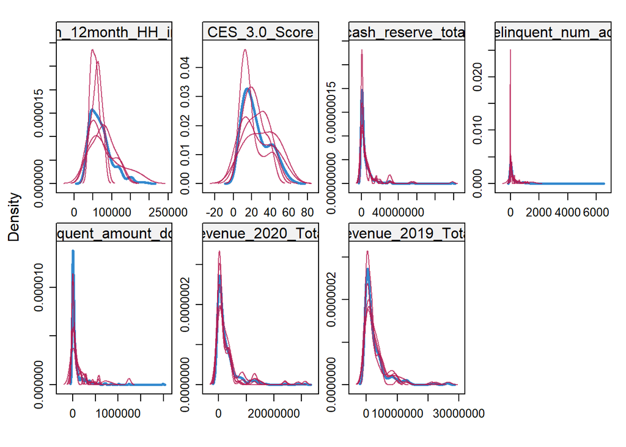

```r
densityplot(imp)
```

Many of these variables seem to be well-predicted by the mode. The worst seems to be CES 3.0 score and 12 month household income. Looking closer.

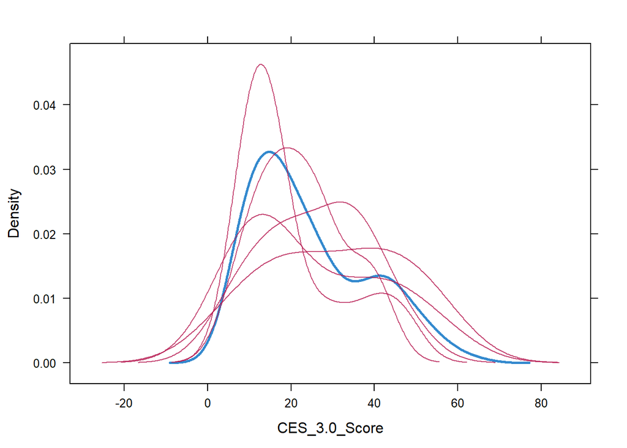

```r
densityplot(imp, ~CES_3.0_Score)
```

We can see here that the model biases towards lower CalEnviroScreen 3.0 scores.

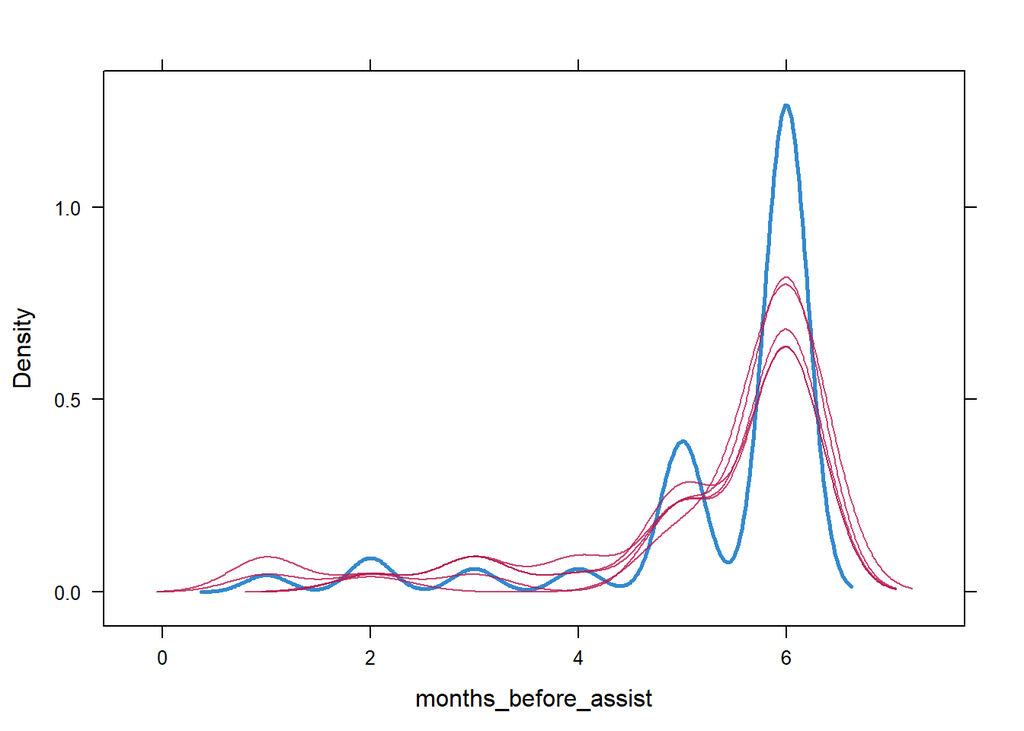

```r
densityplot(imp, ~months_before_assist)
```

This model seems to overestimate the number of systems that will need immediate assistance.

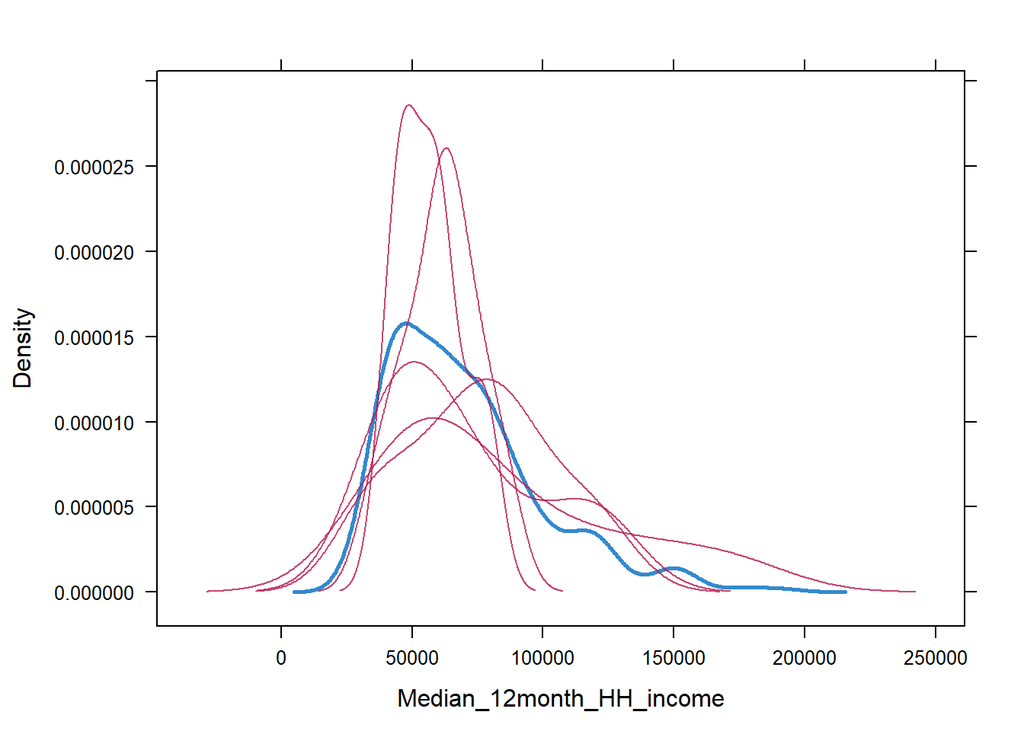

```r
densityplot(imp, ~Median_12month_HH_income)
```

This model has not adequately learned income status.

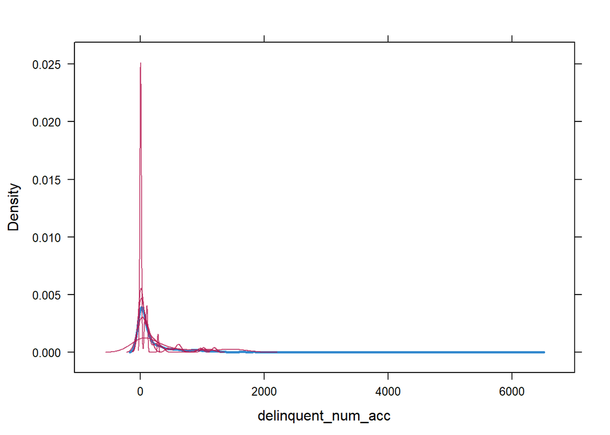

```r
densityplot(imp, ~delinquent_num_acc)
```

Also not great.

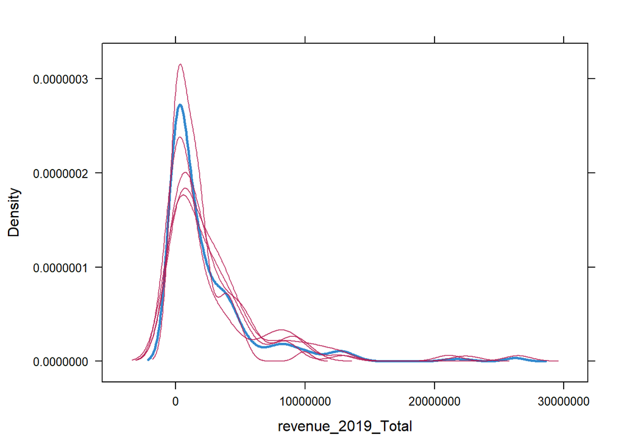

```r
densityplot(imp, ~revenue_2019_Total)
```

Seems ok.

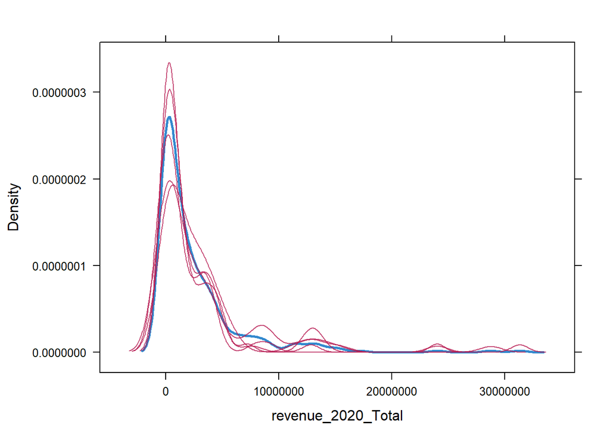

```r
densityplot(imp, ~revenue_2020_Total)
```

Great!

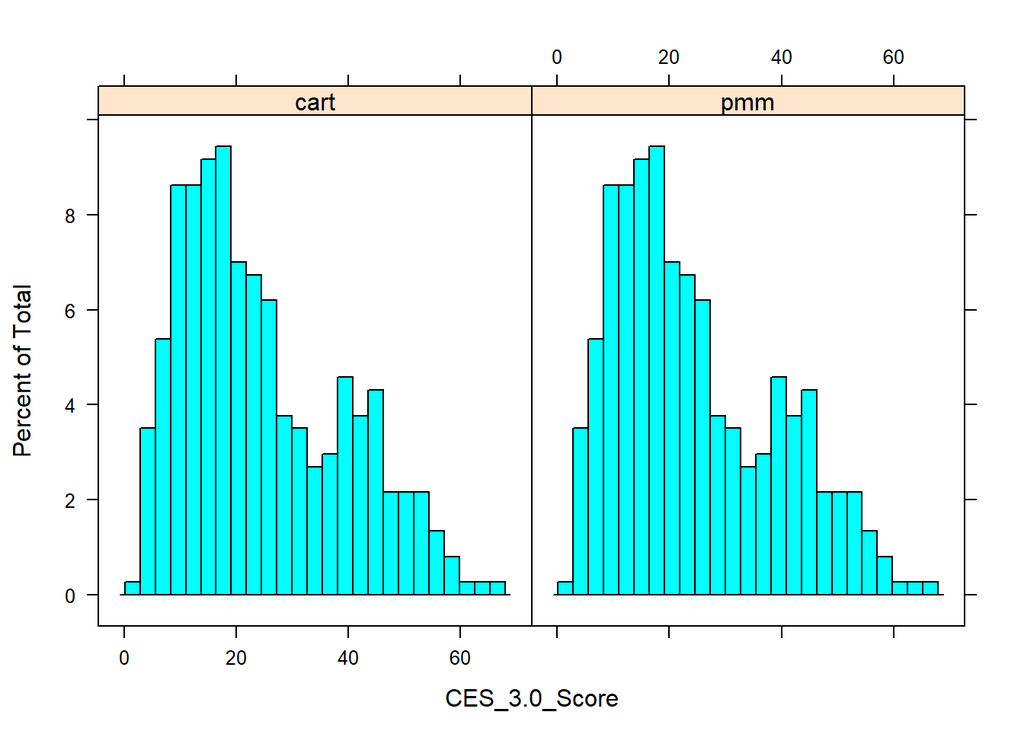

```r
CES_3.0_Score <- c(complete(imp)$CES_3.0_Score, complete(imp)$CES_3.0_Score)
method <- rep(c("pmm", "cart"), each = nrow(allSmalls.simple))
CES_3.0_Score_m <- data.frame(CES_3.0_Score = CES_3.0_Score, method = method)
#plot histogram
histogram( ~CES_3.0_Score | method, data = CES_3.0_Score_m, nint = 25)
```

Now that we are satisfied with the selected imputed variables for dataset, let’s extract the completed data and confirm that there are no additional missing values.

```r
#extract the third imputed data set
simpleImputed <- complete(imp) %>% select(-CES_3.0_Score, -Median_12month_HH_income, -months_before_assist, -Service_Connections)
#the imputed data can also be extracted in long format.
#c.long <- complete(imp, "long")
md.pattern(simpleImputed)
```

```
##  /\     /\
## {  `---'  }
## {  O   O  }
## ==>  V <==  No need for mice. This data set is completely observed.
##  \  \|/  /
##   `-----'
```

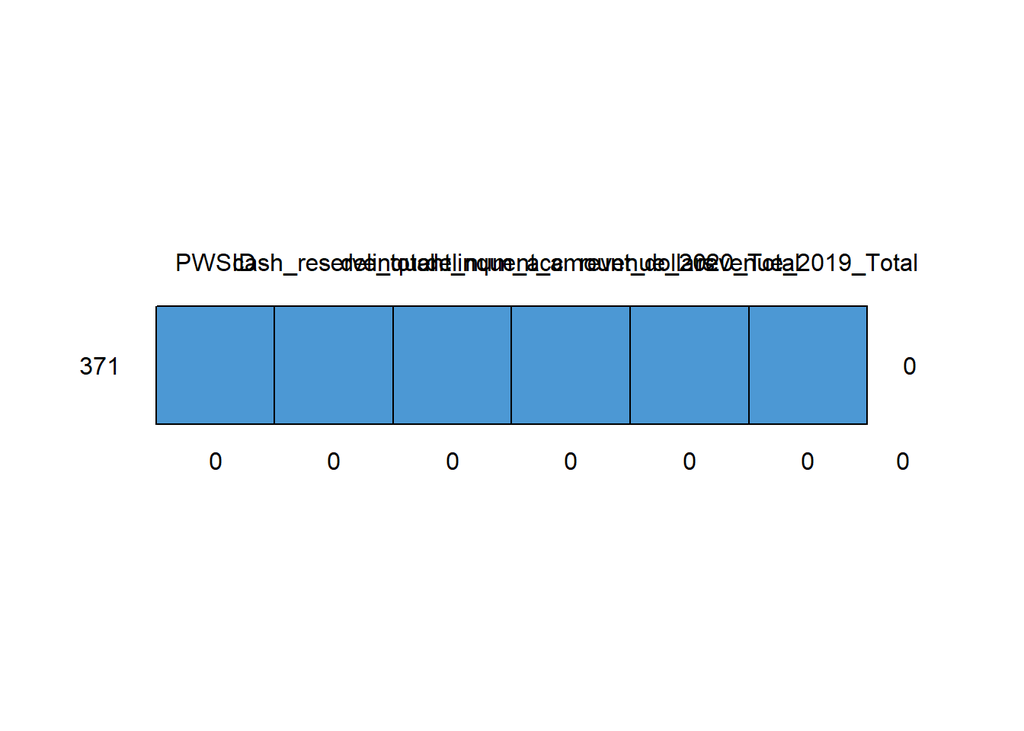

```
##     PWSID cash_reserve_total delinquent_num_acc delinquent_amount_dollars
## 371     1                  1                  1                         1
##         0                  0                  0                         0
##     revenue_2020_Total revenue_2019_Total
## 371                  1                  1 0
##                      0                  0 0
```

Here we can see that all data is completed.

We can also compare summary statistics for the imputed variables with those in the original dataset.

```r
simpleImputed %>%
  mutate(Grp = "Imputed") %>%
  bind_rows(mutate(allSmalls.requested.responded, Grp = "Original"))  %>%
  select(Grp, delinquent_num_acc, delinquent_amount_dollars, revenue_2020_Total, revenue_2019_Total) %>%
  group_by(Grp) %>%
  drop_na() %>%
  summarize_all(list(mean = "mean", median = "median"))
```

```
## # A tibble: 2 x 9
##   Grp      delinquent_num_acc_mean delinquent_amount_dollars_mean
##   <chr>                      <dbl>                          <dbl>
## 1 Imputed                     229.                         81733.
## 2 Original                    250.                         85223.
##   revenue_2020_Total_mean revenue_2019_Total_mean delinquent_num_acc_median
##                     <dbl>                   <dbl>                     <int>
## 1                2530488.                2512076.                        45
## 2                2613894.                2527809.                        66
##   delinquent_amount_dollars_median revenue_2020_Total_median
##                              <dbl>                     <dbl>
## 1                           20726                    1127489
## 2                           22435.                   1275776
##   revenue_2019_Total_median
##                       <dbl>
## 1                  1107283.
## 2                  1134901.
```

Summary stats can be plotted.

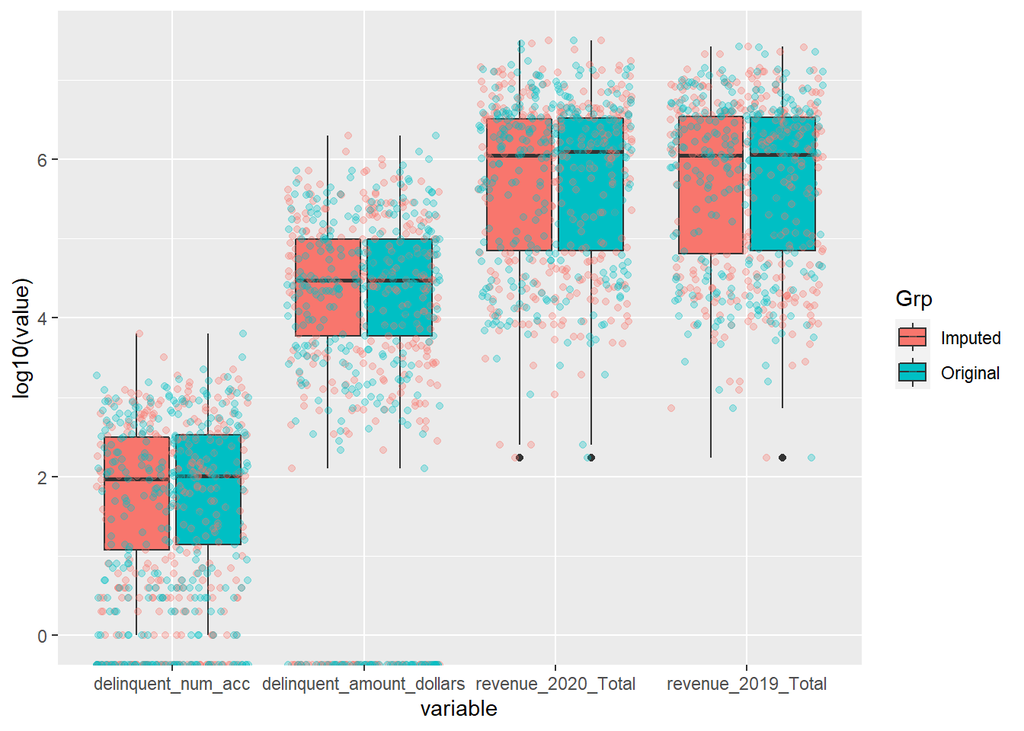

```r
#join data for plotting
simpleImputed %>% mutate(Grp = "Imputed") %>%
  bind_rows(mutate(allSmalls.requested.responded, Grp = "Original"))  %>%
  select(Grp, delinquent_num_acc, delinquent_amount_dollars, revenue_2020_Total, revenue_2019_Total) %>%
  melt() %>% #transforms values and variables to long format
  ggplot(aes(x = variable, y = log10(value))) +
  geom_boxplot(aes(fill = Grp))+
  geom_jitter(aes(color = Grp), alpha = 0.3)
```

We can see that imputation has not noticeably changed the summary statistics of these data. We shall now fill in the dataset with these imputed values.

[figure not shown]

```r
#join data with imputed values to rest of dataset
imputedSmalls <- right_join(simpleImputed, allSmalls.rest, by = "PWSID")
#also split the dataset that has requested but no response data, which we will only use to adjust weights in the next section
allSmalls.requested.voluntary.rest <- allSmalls.requested.voluntary %>%
  select(-cash_reserve_total, -delinquent_num_acc, -delinquent_amount_dollars, -revenue_2020_Total, -revenue_2019_Total)
#join
imputedSmalls.requested.voluntary <- right_join(simpleImputed, allSmalls.requested.voluntary.rest, by = "PWSID")
rm(allSmalls.requested.voluntary.rest)
rm(allSmalls.rest)
rm(imp)
rm(imp2)
rm(fitols)
rm(allSmalls.simple2)
rm(allSmalls.simple_long)
rm(allSmalls.simple_long_1)
rm(allSmalls.simple_long_mids)
rm(allSmalls.simple_long_mids_1)
rm(fitimp)
rm(fitimp_1)
rm(ini)
rm(CES_3.0_Score_m)
#visualize remaining missing values
md.pattern(imputedSmalls)
```

Note that some variables are still missing, however these were deliberately not imputed either due to no being applicable (such as binned data) or would were calculated from other variables.

## Response Propensity Adjustment

Now that we have designed our basic weights, we now need to account for differences in the propensity to respond. It’s possible that certain profiles (e.g. lower income communities) had different propensities to respond than another profile (e.g. higher income communities). We could then imagine that the characteristics of both profiles were associated with reponse variables that we collected in this survey (e.g. water systems with lower income having more delinquent accounts than higher income systems). As we then would have a larger proportion of higher income/fewer delinquent accounts in our sample, our analyses would be biased.

First let’s see the response rate for each of the bins.

```r
allSmalls %>% group_by(tag) %>% filter(requested == "y") %>%
  summarize(completeness = sum(response)/n() * 100 , completed = sum(response), total = n())
```

```
## # A tibble: 4 x 4
##   tag   completeness completed total
##   <fct>        <dbl>     <dbl> <int>
## 1 Bin A         67.5       154   228
## 2 Bin B         72.9        97   133
## 3 Bin C         82.1        69    84
## 4 Bin D         78.5        51    65
```

Computing the probability of replying to this survey is challenging because we can not directly observe the probability of replying to the survey, therefore we need to estimate it. This may be done using information which we know for both respondent and non-respondent units. The most reliable (albeit most complicated) of calculating non-response probabilities is through predictive modelling.

```r
#trim data to those in sample list with auxiliary data
allSmalls.requested.response.model <- allSmalls %>%
  filter(requested == "y") %>%
  select(response, Service_Connections, Population, CES_3.0_Score, Median_12month_HH_income,
         Median_rent_pct_income) %>%
  drop_na()

#prepare formula
formula.resp <- as.formula("response ~ Service_Connections + Population + CES_3.0_Score + Median_12month_HH_income + Median_rent_pct_income")
options(na.action = 'na.pass')

#format as matrix
x.matrix <- model.matrix(formula.resp , data = allSmalls.requested.response.model)[, -1]

#fit binomial model
log.reg.m <- glm(formula.resp, data = allSmalls.requested.response.model,family = "binomial")

coef.response.log <- coef(log.reg.m)
predicted.log <- log.reg.m$fitted.values
non.responsepredicted.log <- predicted.log

predicted.log %>% head()
```

```
##         1         2         3         4         5         6
## 0.8703461 0.7392626 0.8655408 0.9114733 0.8905100 0.5794538
```

The above output shows the first six estimated response propensities of our dataset. Since we don’t have pardata for all samples, we are now computing our predictor estimates from a subset of sampled units.

Let’s define our survey structure in the *survey* package.

```r
##### Specify sampling design ####
#here we will use our imputed survey dataset
#(stratified)
srv.dsgn <- svydesign(data = imputedSmalls,
                        weights = ~base.weight, #if weighted. Don't forget tilde ~
                        fpc = ~fpc, #population size for each stratum
                        strata = ~tag, #bins
                        id = ~1) #specifies independent sampling (without replacement)
#specify replicate survey design
rclus1 <- as.svrepdesign(srv.dsgn)
#print summary of design
summary(srv.dsgn)
```

[output not shown]

First let’s start by testing which variables are predictive of response.

```r
#redefine all smalls
allSmalls.requested <- allSmalls %>% filter(requested == "y")
#fit
fitResponse <- lm(response ~ Service_Connections + Population + Median_12month_HH_income + Median_rent_pct_income + CES_3.0_Score + Fee_Code, na.action = na.omit, data = allSmalls.requested)
summary(fitResponse)
```

```
##
## Call:
## lm(formula = response ~ Service_Connections + Population + Median_12month_HH_income +
##     Median_rent_pct_income + CES_3.0_Score + Fee_Code, data = allSmalls.requested,
##     na.action = na.omit)
##
## Residuals:
##     Min      1Q  Median      3Q     Max
## -0.9158 -0.5981  0.2313  0.3057  0.5302
##
## Coefficients:
##                               Estimate    Std. Error t value Pr(>|t|)
## (Intercept)               0.6826891707  0.1765457230   3.867 0.000125 ***
## Service_Connections       0.0000418843  0.0000202749   2.066 0.039376 *
## Population               -0.0000074645  0.0000043509  -1.716 0.086871 .
## Median_12month_HH_income -0.0000003250  0.0000008822  -0.368 0.712762
## Median_rent_pct_income    0.0033984795  0.0037709554   0.901 0.367916
## CES_3.0_Score            -0.0027866305  0.0017033705  -1.636 0.102499
## Fee_CodeDAVCL             0.0842018936  0.0658133935   1.279 0.201367
## Fee_CodeDAVCS             0.0039998124  0.1135471346   0.035 0.971914
## Fee_CodeSC               -0.0390688342  0.0632269529  -0.618 0.536922
## ---
## Signif. codes:  0 '***' 0.001 '**' 0.01 '*' 0.05 '.' 0.1 ' ' 1
##
## Residual standard error: 0.4403 on 485 degrees of freedom
##   (16 observations deleted due to missingness)
## Multiple R-squared:  0.03724,    Adjusted R-squared:  0.02136
## F-statistic: 2.345 on 8 and 485 DF,  p-value: 0.01764
```

```r
#be sure to use the dataset with non-response data
out <- pclass(formula = response ~ Service_Connections + Population + Fee_Code,
              data = allSmalls.requested,
              type = "unwtd", #already have base weights
              link = "logit",
              numcl = 4) #classes to create
table(out$p.class, useNA = "always") # ensures no unit has a missing class value
```

```
##
## [0.381,0.672] (0.672,0.706] (0.706,0.789] (0.789,0.916]          <NA>
##           128           127           127           128             0
```

Further examine propensities.

```r
summary(out$propensities)
```

```
##    Min. 1st Qu.  Median    Mean 3rd Qu.    Max.
##  0.3805  0.6717  0.7059  0.7275  0.7887  0.9157
```

These propensity classes can be viewed in boxplot form.

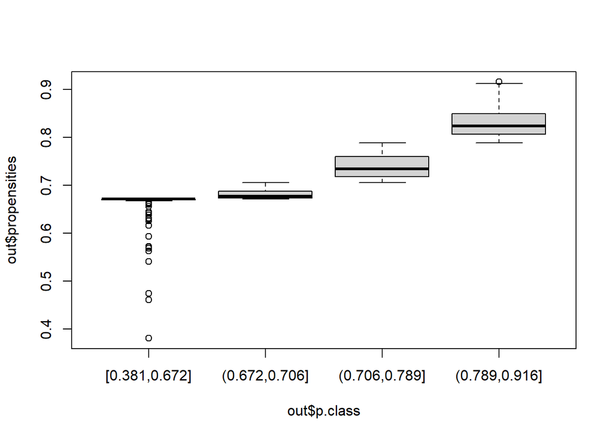

```r
boxplot(out$propensities ~ out$p.class)
```

```r
cbind(
  "mean" = by(data = out$propensities, INDICES = out$p.class, FUN = mean),
  "median" = by(data = out$propensities, INDICES = out$p.class, FUN = median),
  "weighted" = by(data = data.frame(preds = out$propensities, wt = allSmalls.requested[,"base.weight"]), out$p.class, function(x) {weighted.mean(x$preds, x$wt)}))
```

```
##                    mean    median  weighted
## [0.381,0.672] 0.6578489 0.6708017 0.6672221
## (0.672,0.706] 0.6816801 0.6766302 0.6787457
## (0.706,0.789] 0.7394551 0.7342263 0.7308477
## (0.789,0.916] 0.8305551 0.8240466 0.8286492
```

We can see that these are all quite similiar. So weighting by the base weights may not be necessary or distinct. Just to ensure, let’s perform a check on covariate balance by fitting an ANOVA model to service connections, which is continuous. We do not use the survey weights below since the interest is in whether balance has been achieved in the sample that was selected. Checks could be made using the weights, in which case the check would be on whether the census-fit model shows evidence of balance.

```r
#extract classes
p.class <- out$p.class
#build glm
chk1 <- glm(Service_Connections ~ p.class + response + p.class*response,
data = allSmalls.requested)
#print
summary(chk1)
```

```
##
## Call:
## glm(formula = Service_Connections ~ p.class + response + p.class *
##     response, data = allSmalls.requested)
##
## Deviance Residuals:
##     Min       1Q   Median       3Q      Max
## -4433.5   -701.6   -456.0    634.2   8968.4
##
## Coefficients:
##                               Estimate Std. Error t value             Pr(>|t|)
## (Intercept)                     713.57     264.98   2.693             0.007320
## p.class(0.672,0.706]            118.73     430.25   0.276             0.782698
## p.class(0.706,0.789]           1617.43     453.47   3.567             0.000396
## p.class(0.789,0.916]           4764.93     477.71   9.975 < 0.0000000000000002
## response                       -237.57     348.50  -0.682             0.495745
## p.class(0.672,0.706]:response    41.73     526.01   0.079             0.936802
## p.class(0.706,0.789]:response   808.02     543.30   1.487             0.137577
## p.class(0.789,0.916]:response   256.81     562.05   0.457             0.647923
##
## (Intercept)                   **
## p.class(0.672,0.706]
## p.class(0.706,0.789]          ***
## p.class(0.789,0.916]          ***
## response
## p.class(0.672,0.706]:response
## p.class(0.706,0.789]:response
## p.class(0.789,0.916]:response
## ---
## Signif. codes:  0 '***' 0.001 '**' 0.01 '*' 0.05 '.' 0.1 ' ' 1
##
## (Dispersion parameter for gaussian family taken to be 3791673)
##
##     Null deviance: 3954740357  on 509  degrees of freedom
## Residual deviance: 1903419634  on 502  degrees of freedom
## AIC: 9182.9
##
## Number of Fisher Scoring iterations: 2
```

```r
chk2 <- glm(Service_Connections ~ p.class, data = allSmalls.requested)
anova(chk2, chk1, test="F")
```

```
## Analysis of Deviance Table
##
## Model 1: Service_Connections ~ p.class
## Model 2: Service_Connections ~ p.class + response + p.class * response
##   Resid. Df Resid. Dev Df Deviance      F Pr(>F)
## 1       506 1913228306
## 2       502 1903419634  4  9808672 0.6467 0.6294
```